# Draft Strategy Guide

# Principle 6: Closers — Pay for the Elite, Ignore the Rest

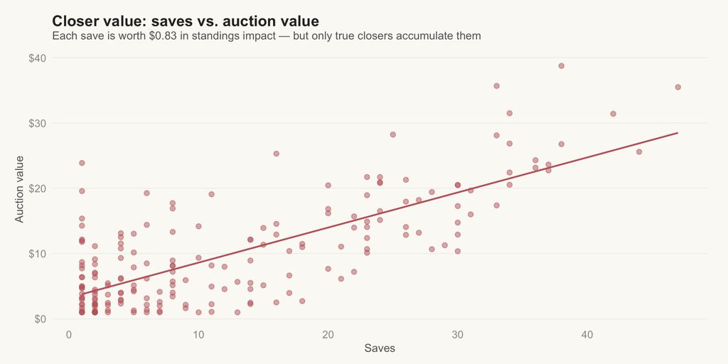

```r
closer_data <- all_val |>
  filter(is_pitcher, SV > 0, auction_value > 0)

closer_data |>
  ggplot(aes(x = SV, y = auction_value)) +
  geom_point(color = pal$secondary, alpha = 0.5, size = 2) +
  geom_smooth(method = "lm", se = FALSE, color = pal$secondary, linewidth = 0.8) +
  scale_y_continuous(labels = dollar_format(prefix = "$")) +
  labs(
    title = "Closer value: saves vs. auction value",
    subtitle = "Each save is worth $0.83 in standings impact — but only true closers accumulate them",
    x = "Saves", y = "Auction value"
  )
```

Saves have a denominator of 6.4, making each save worth **$0.83** — significant per-unit value. But saves are the most binary stat in baseball: you’re either the closer or you’re not. In 2024, Emmanuel Clase led with 47 saves (7.3 SV SGP), while the 10th-best closer had only 23 saves (3.6 SGP). The drop-off is steep.

The relationship between saves and total auction value is positive but noisy because closers also generate value from ERA, WHIP, and SO. The elite closers (Clase, Hader, Yates) who combine saves with strong ratios can be worth $25-35, rivaling mid-tier starters.

**The draft implication:** there are only about 10-12 true closers in AL-only. If you want to compete in saves, you need at least one elite closer (30+ SV). Paying $20-25 for a Clase-tier closer is reasonable because the 7+ SGP from saves alone is worth ~$37 in standings impact. Middle-tier closers (15-20 SV) offer less value per dollar because they don’t accumulate enough saves to dominate the category, and their other stat contributions are modest. Either go big or punt saves entirely and reinvest elsewhere.

# Principle 7: Multi-Category Hitters Are the Best Value

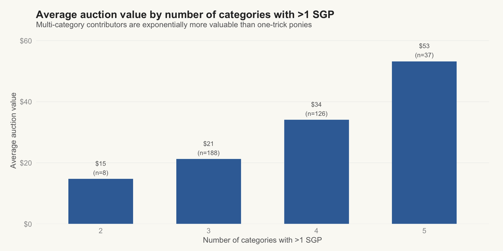

```r
multi_cat <- all_val |>
  filter(!is_pitcher, auction_value > 10) |>
  mutate(
    cats_above_1 = (sgp_R > 1) + (sgp_HR > 1) + (sgp_RBI > 1) +
                   (sgp_SB > 1) + (sgp_AVG > 1),
    cats_above_1 = factor(cats_above_1)
  )

cat_value <- multi_cat |>
  group_by(cats_above_1) |>
  summarise(
    n = n(),
    avg_auction = mean(auction_value),
    avg_surplus = mean(surplus, na.rm = TRUE),
    .groups = "drop"
  )

cat_value |>
  ggplot(aes(x = cats_above_1, y = avg_auction)) +
  geom_col(fill = pal$primary, width = 0.6) +
  geom_text(aes(label = paste0("$", round(avg_auction), "\n(n=", n, ")")),
            vjust = -0.3, size = 3.2, color = pal$mid) +
  scale_y_continuous(labels = dollar_format(prefix = "$"),
                     expand = expansion(mult = c(0, 0.15))) +
  labs(
    title = "Average auction value by number of categories with >1 SGP",
    subtitle = "Multi-category contributors are exponentially more valuable than one-trick ponies",
    x = "Number of categories with >1 SGP", y = "Average auction value"
  )
```

The 5-category players ($53 avg) are the Jose Ramirezes and Bobby Witts of the world — they hit for power, speed, average, and produce counting stats. The 3-category players ($21 avg) are more common: a solid power hitter who drives in runs and scores but doesn’t steal or hit for high average.

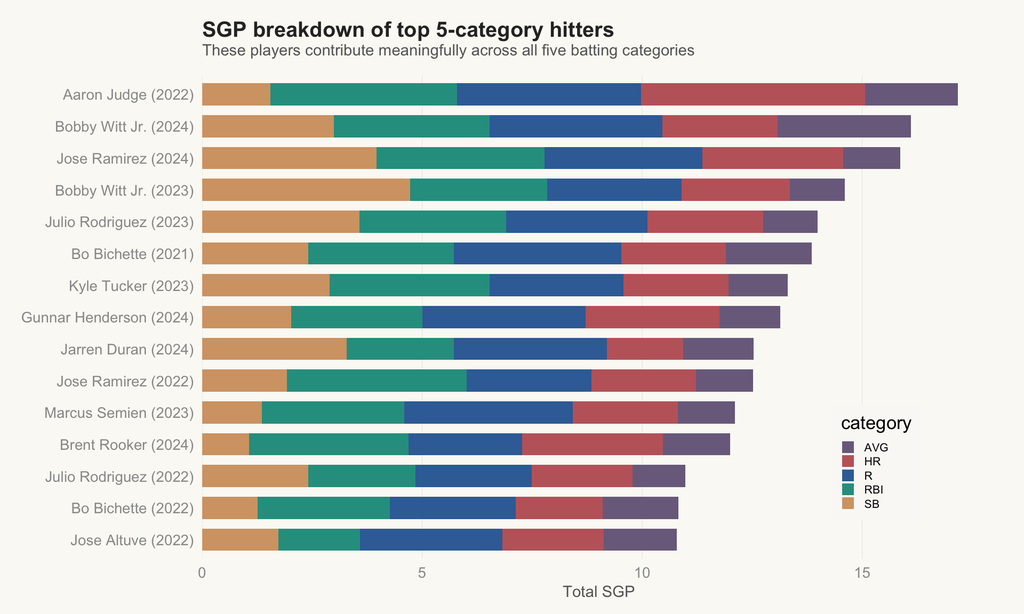

```r
# Show what the 5-category players look like
five_cat <- multi_cat |>
  filter(cats_above_1 == 5) |>
  arrange(desc(auction_value)) |>
  head(15)

five_cat_long <- five_cat |>
  select(player_name, year, sgp_R, sgp_HR, sgp_RBI, sgp_SB, sgp_AVG) |>
  pivot_longer(cols = starts_with("sgp_"), names_to = "category", values_to = "sgp") |>
  mutate(category = str_remove(category, "sgp_"))

five_cat_long |>
  ggplot(aes(x = sgp, y = fct_reorder(paste0(player_name, " (", year, ")"), sgp, .fun = sum),
             fill = category)) +
  geom_col(position = "stack", width = 0.7) +
  scale_fill_manual(values = c(
    "R" = "#3A6EA5", "HR" = "#C1666B", "RBI" = "#2A9D8F",
    "SB" = "#D4A373", "AVG" = "#7B6D8D"
  )) +
  scale_x_continuous(expand = expansion(mult = c(0, 0.05))) +
  labs(
    title = "SGP breakdown of top 5-category hitters",
    subtitle = "These players contribute meaningfully across all five batting categories",
    x = "Total SGP", y = NULL
  ) +
  h_grid +
  theme(
    legend.position = c(0.85, 0.2),
    legend.direction = "vertical",
    legend.text = element_text(size = 8),
    legend.key.size = unit(0.35, "cm"),
    legend.background = element_rect(fill = alpha(pal$bg, 0.9), color = NA)
  )
```

**The draft implication:** when choosing between two players at a similar price, prefer the one who contributes across more categories. A .280 hitter with 25 HR, 15 SB, 90 R, and 85 RBI is more valuable than a .240 hitter with 40 HR, 0 SB, 80 R, and 100 RBI — even though the second player might look more impressive on the back of his baseball card. The five-tool player helps you in five standings races; the one-dimensional slugger helps in two.

# Principle 8: Keepers Create the Biggest Edges

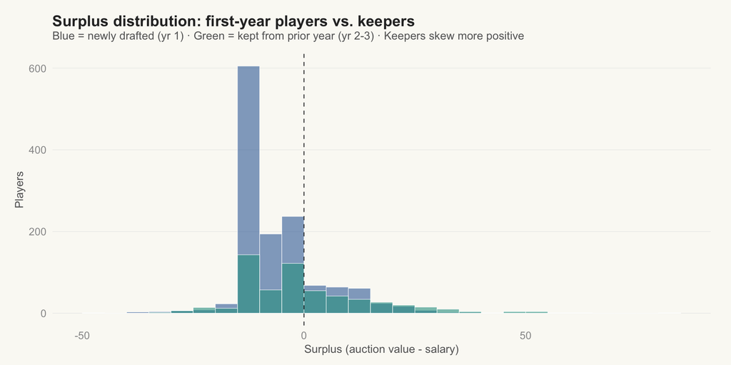

```r
keeper_data <- all_val |>
  filter(!is.na(surplus), !is.na(contract_year)) |>
  mutate(
    keeper_status = case_when(
      contract_year %in% c("b", "c", "bX", "cX", "bY", "cY") ~ "Keeper (yr 2-3)",
      contract_year %in% c("a", "aX", "aY") ~ "First year (yr 1)",
      TRUE ~ "Other"
    )
  ) |>
  filter(keeper_status != "Other")

keeper_data |>
  ggplot(aes(x = surplus, fill = keeper_status)) +
  geom_histogram(binwidth = 5, boundary = 0, color = "white", linewidth = 0.2,
                 position = "identity", alpha = 0.6) +
  geom_vline(xintercept = 0, linetype = "dashed", color = pal$text, linewidth = 0.4) +
  scale_fill_manual(values = c("First year (yr 1)" = pal$primary,
                                "Keeper (yr 2-3)" = pal$accent)) +
  labs(
    title = "Surplus distribution: first-year players vs. keepers",
    subtitle = "Blue = newly drafted (yr 1) · Green = kept from prior year (yr 2-3) · Keepers skew more positive",
    x = "Surplus (auction value - salary)", y = "Players"
  )
```

First-year players (newly drafted) average **-$5 in surplus** — the league collectively overpays at auction. But players kept from prior years (contract year b or c) average **+$1 in surplus**. The gap seems small until you consider scale: across a full roster of keepers, that +$6/player swing adds up fast.

The mechanism is straightforward: when a player breaks out or takes a leap, their salary stays fixed at the original auction price while their value increases. The keeper retains the surplus. This is the single biggest edge-generating mechanism in a keeper league — and it’s why scouting breakout candidates in years before they peak is so important.

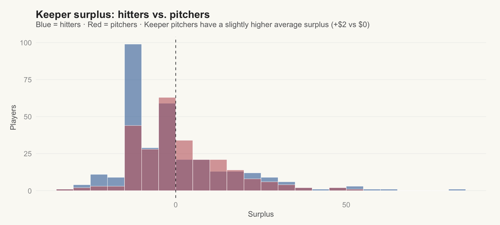

```r
# Keeper hitters vs pitchers
keeper_data |>
  filter(keeper_status == "Keeper (yr 2-3)") |>
  ggplot(aes(x = surplus, fill = pos_type)) +
  geom_histogram(binwidth = 5, boundary = 0, color = "white", linewidth = 0.2,
                 position = "identity", alpha = 0.6) +
  geom_vline(xintercept = 0, linetype = "dashed", color = pal$text, linewidth = 0.4) +
  scale_fill_manual(values = c("Hitter" = pal$primary, "Pitcher" = pal$secondary)) +
  labs(
    title = "Keeper surplus: hitters vs. pitchers",
    subtitle = "Blue = hitters · Red = pitchers · Keeper pitchers have a slightly higher average surplus (+$2 vs $0)",
    x = "Surplus", y = "Players"
  )
```

Interestingly, **kept pitchers (+$2 avg surplus) slightly outperform kept hitters (+$0)**. This runs counter to the common wisdom that pitcher keepers are riskier. The data suggests that when pitchers *do* maintain their performance through a second or third year, the surplus is real. The risk is that pitchers are more likely to get injured or decline — but the ones who survive the filter are worth keeping.

**The draft implication:** your draft strategy should start with your keeper list. Every keeper retained at below-market price frees up budget for the auction. The ideal draft starts with 3-5 keepers who collectively generate +$30-50 of surplus, then deploys the freed-up budget to fill gaps. The worst outcome is keeping players whose salary has caught up to or exceeded their value — that’s dead money locked in for the season.

# Summary: The Draft Cheat Sheet

**Draft Strategy Summary**

Eight principles derived from five seasons of SGP analysis

| Principle | What the Data Says |
| --- | --- |
| Balance > Stars | Top-heavy rosters correlate with -$75 worse surplus than balanced ones (r = -0.36) |
| Target SS and 3B | SS and 3B average +$14 surplus — the league's biggest positional market inefficiency |
| Pay for aces | Ace starters (180+ IP) produce $45 of value but cost only $25 on average |
| Lock up speed | Each SB is worth $0.51 and only ~12 players steal 30+ — cornering speed pays off |
| Diversify wins | Each W is worth $1.77 but wins are noisy — spread your bets across 3-4 starters |
| Closers: elite or none | Only ~10 true closers exist in AL-only — a 40-SV closer generates 6+ SGP from saves alone |
| 5-tool hitters > sluggers | 5-category hitters ($53 avg) are worth 3.5x more than 2-category hitters ($15 avg) |
| Keepers are your edge | Keepers average +$6 more surplus than first-year draft picks — breakout scouting is the highest-ROI activity |